# BUA 455 - Week 3: Reshaping and Summarizing Data

Penelope Pooler Eisenbies

2024-02-01

```r
# this line specifies options for default options for all R Chunks
knitr::opts_chunk$set(echo=T,
                      highlight=T)

# suppress scientific notation
options(scipen=100)

# install helper package (pacman) if needed
if (!require("pacman")) install.packages("pacman", repos = "http://lib.stat.cmu.edu/R/CRAN/")
# install and load required packages
# pacman should be first package in parentheses and then list others
pacman::p_load(pacman, tidyverse, gridExtra, magrittr, lubridate, kableExtra)

# verify packages (comment out in finished documents)
p_loaded()
```

```
##  [1] "kableExtra" "magrittr"   "gridExtra"  "lubridate"  "forcats"
##  [6] "stringr"    "dplyr"      "purrr"      "readr"      "tidyr"
## [11] "tibble"     "ggplot2"    "tidyverse"  "pacman"
```

### Reminders from Week 2 and HW 2:

#### HW 2 is Due 1/31

##### `dplyer` commands:

- `select` - used to select variables (columns) of a dataset
- `slice` - used to select rows by row number
- `filter` - used to filter data rows by values of a variable
- `mutate` - to create or transform a variable

##### `ggplot` introduction:

- basic syntax and aesthetics statements (`aes`)
- creating a basic boxplot (`geom_boxplot`) or scatterplot (`geom_point`)
- removing default background by modifying the theme
- adding a a third categorical variable to color the data by category

### Answer to Question about Reordering variables

The R command **[relocate](https://dplyr.tidyverse.org/reference/relocate.html)** in the `dplyr` package can be used to reorder variables by type

```r
my_starwars <- starwars |>
  select(1:11) |>
  relocate(where(is.numeric)) |>
  glimpse(width=40)
```

```
## Rows: 87
## Columns: 11
## $ height     <int> 172, 167, 96, 202, …
## $ mass       <dbl> 77, 75, 32, 136, 49…
## $ birth_year <dbl> 19.0, 112.0, 33.0, …
## $ name       <chr> "Luke Skywalker", "…
## $ hair_color <chr> "blond", NA, NA, "n…
## $ skin_color <chr> "fair", "gold", "wh…
## $ eye_color  <chr> "blue", "yellow", "…
## $ sex        <chr> "male", "none", "no…
## $ gender     <chr> "masculine", "mascu…
## $ homeworld  <chr> "Tatooine", "Tatooi…
## $ species    <chr> "Human", "Droid", "…
```

```r
my_starwars <- starwars |>
  select(1:11) |>
  relocate(where(is.character)) |>
  glimpse(width=40)
```

```
## Rows: 87
## Columns: 11
## $ name       <chr> "Luke Skywalker", "…
## $ hair_color <chr> "blond", NA, NA, "n…
## $ skin_color <chr> "fair", "gold", "wh…
## $ eye_color  <chr> "blue", "yellow", "…
## $ sex        <chr> "male", "none", "no…
## $ gender     <chr> "masculine", "mascu…
## $ homeworld  <chr> "Tatooine", "Tatooi…
## $ species    <chr> "Human", "Droid", "…
## $ height     <int> 172, 167, 96, 202, …
## $ mass       <dbl> 77, 75, 32, 136, 49…
## $ birth_year <dbl> 19.0, 112.0, 33.0, …
```

### New Skills in Week 3 (and HW 3)

- Importing a ‘clean’ dataset
  - After Quiz 1 we’ll cover how to clean ‘messy’ data
- Creating a character or factor variable
- Coercing data to be a new data type
- Summarizing data and reshaping data for a summary table
- Reshaping data for a plot

#### Preview of ‘cleaning’ messy

- Examine Raw Messy Data
  - remove non-data rows at the top with skip
  - select variables and filter data rows
  - remove nuisance characters like `$` and `,`
  - work with date information variables
  - export and save a clean dataset

### Original Data

Online Data are often formatted for viewing, not using.

- Details that make online data viewing easier, have to be removed for data management.

[figure not shown]

Box Office Mojo daily data from 2022

[Data Source: Box Office Mojo](https://www.boxofficemojo.com/daily/2022/?view=year)

### Raw Data (.csv)

Copying data from a website and saving them as a .csv file (CSV UTF-8) removes most of the formatting, but data cleaning is still required.

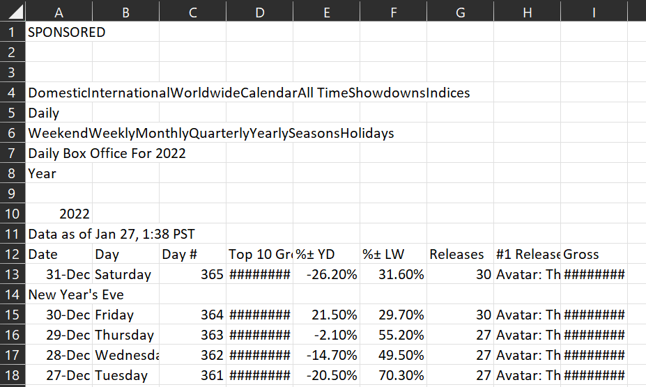

Box Office Mojo daily data from 2022 saved as .csv file

### Import, Select, Filter

- `read_csv` imports the raw data and skips the first 11 rows (above the variable names).
- `filter` is used to filter out rows that don’t contain data
- `select` is used to select only the variables we need
- `rename` (new command) is used to make the variable names easier to work with
- `head` is one of many options for examining the data

```r
bom22 <- read_csv("box_office_mojo_2022.csv", skip=11, show_col_types = FALSE) |>
  filter(!is.na(Day)) |>
  select(Date, `Top 10 Gross`, Gross, Releases, `#1 Release`) |>
  rename(date=Date, top10gross = `Top 10 Gross`,
         num_releases=Releases, num1gross=Gross, num1 = `#1 Release`)
head(bom22)
```

```
## # A tibble: 6 × 5
##   date   top10gross  num1gross   num_releases num1
##   <chr>  <chr>       <chr>              <dbl> <chr>
## 1 31-Dec $27,962,493 $18,053,159           30 Avatar: The Way of Water
## 2 30-Dec $37,900,613 $24,836,835           30 Avatar: The Way of Water
## 3 29-Dec $31,204,428 $20,117,061           27 Avatar: The Way of Water
## 4 28-Dec $31,866,473 $20,582,014           27 Avatar: The Way of Water
## 5 27-Dec $37,343,124 $24,128,503           27 Avatar: The Way of Water
## 6 26-Dec $46,963,277 $32,270,430           28 Avatar: The Way of Water
```

### Clean Numeric Data

- The two **Gross** variables both contained `$` and `,` symbols that were removed with `gsub`.
- Each variable was then converted to numeric with `as.numeric`.

```r
bom22 <- bom22 |>
  mutate(top10gross = gsub(x=top10gross, pattern="$", replacement="", fixed=T),
         top10gross = gsub(x=top10gross, pattern=",", replacement="", fixed=T) |>
           as.numeric(),

         num1gross = gsub(x=num1gross, pattern="$", replacement="", fixed=T),
         num1gross = gsub(x=num1gross, pattern=",", replacement="", fixed=T) |>
           as.numeric())
head(bom22)
```

```
## # A tibble: 6 × 5
##   date   top10gross num1gross num_releases num1
##   <chr>       <dbl>     <dbl>        <dbl> <chr>
## 1 31-Dec   27962493  18053159           30 Avatar: The Way of Water
## 2 30-Dec   37900613  24836835           30 Avatar: The Way of Water
## 3 29-Dec   31204428  20117061           27 Avatar: The Way of Water
## 4 28-Dec   31866473  20582014           27 Avatar: The Way of Water
## 5 27-Dec   37343124  24128503           27 Avatar: The Way of Water
## 6 26-Dec   46963277  32270430           28 Avatar: The Way of Water
```

### Date Variables

- Dealing with date variables used to be much more difficult (prior to `lubridate` package).
- Dates are still troublesome in most other software
- Below we create a date variable from the provided character variable, create other variables, examine data and export the dataset.

```r
bom22 <- bom22 |>
  mutate(date = dmy(paste(date,"-","2022")), # year is required so we paste it (add it as text) to each date
         month = month(date, label=T, abbr=T),
         day = wday(date, label=T, abbr=T),
         quart = quarter(date)) |>
  select(date, month, day, quart, top10gross:num1) |>  # select and reorder variables
  glimpse() |>                                         # examine data
  write_csv("Box_Office_Mojo_Week3_HW3.csv")           # export using write_csv
```

```
## Rows: 365
## Columns: 8
## $ date         <date> 2022-12-31, 2022-12-30, 2022-12-29, 2022-12-28, 2022-12-…
## $ month        <ord> Dec, Dec, Dec, Dec, Dec, Dec, Dec, Dec, Dec, Dec, Dec, De…
## $ day          <ord> Sat, Fri, Thu, Wed, Tue, Mon, Sun, Sat, Fri, Thu, Wed, Tu…
## $ quart        <int> 4, 4, 4, 4, 4, 4, 4, 4, 4, 4, 4, 4, 4, 4, 4, 4, 4, 4, 4, …
## $ top10gross   <dbl> 27962493, 37900613, 31204428, 31866473, 37343124, 4696327…
## $ num1gross    <dbl> 18053159, 24836835, 20117061, 20582014, 24128503, 3227043…
## $ num_releases <dbl> 30, 30, 27, 27, 27, 28, 27, 27, 27, 29, 30, 30, 29, 30, 2…
## $ num1         <chr> "Avatar: The Way of Water", "Avatar: The Way of Water", "…
```

### Importing Clean Data

- `read_csv` is used in this class
- External datasets should be saved as `.csv` files to your `code_data_output` folder
  - There are many CSV file options.
  - Select **CSV UTF-8** when saving Excel datasets as `.csv` files.
- `show_col_types=F` suppresses the output message from importing data
  - This option will be required when you create a dashboard.

```r
mojo_22 <- read_csv("Box_Office_Mojo_Week3_HW3.csv", show_col_types=F) |>
  glimpse(width=60)
```

```
## Rows: 365
## Columns: 8
## $ date         <date> 2022-12-31, 2022-12-30, 2022-12-29, …
## $ month        <chr> "Dec", "Dec", "Dec", "Dec", "Dec", "D…
## $ day          <chr> "Sat", "Fri", "Thu", "Wed", "Tue", "M…
## $ quart        <dbl> 4, 4, 4, 4, 4, 4, 4, 4, 4, 4, 4, 4, 4…
## $ top10gross   <dbl> 27962493, 37900613, 31204428, 3186647…
## $ num1gross    <dbl> 18053159, 24836835, 20117061, 2058201…
## $ num_releases <dbl> 30, 30, 27, 27, 27, 28, 27, 27, 27, 2…
## $ num1         <chr> "Avatar: The Way of Water", "Avatar: …
```

### Week 3 In-class Exercises (L5 - Q1)

*Session ID: bua455f24*

Notice that in the prior chunk, we use the command `read_csv`

**True or False:**

`read_csv` and `read.csv` are the same and can be used interchangeably to import data.

**Hint** Two ways to determine this:

1. R help: In console type ?read_csv and/or type ?read.csv and look through documentation
2. Google **R read_csv and read.csv**

**Note:** R help files are sometimes hard to decipher and **Googling** often requires time and effort but both are essential to learning to code and manage data independently.

### Categorical Data Management

This data set is **ALMOST** ready to work with BUT there are few tasks we will cover:

- select all variables in dataset EXCEPT **`num1`** (name of number 1 movie)
  - We will work with text (character) variables after Quiz 1
- Convert `month` to an ordinal factor, `monthF`
- Convert `day` (of the week) to an ordinal factor, `wkdayF`, with Monday as 1st Day
  - Change `wkdayF` labels to be `M, T, W, Th, F, Sa, Su`
- Convert quart (Quarter) to an ordinal factor with text labels (HW 3)

In HW Assignment 3:

- You will create a factor variable **`quartF`** with
  - levels: 1,2,3,4
  - labels: “1st Qtr”, “2nd Qtr”, “3rd Qtr”, “4th Qtr”
- Create a publication quality table showing data by week day and quarter.

### Exclude `num1`

Recall that we use `!` to exclude a variable or filter out observations

```r
mojo_22_mod <- mojo_22 |>            # save as new dataset
  select(!num1) |>                   # excludes text variable num1 #<<
  glimpse()
```

```
## Rows: 365
## Columns: 7
## $ date         <date> 2022-12-31, 2022-12-30, 2022-12-29, 2022-12-28, 2022-12-…
## $ month        <chr> "Dec", "Dec", "Dec", "Dec", "Dec", "Dec", "Dec", "Dec", "…
## $ day          <chr> "Sat", "Fri", "Thu", "Wed", "Tue", "Mon", "Sun", "Sat", "…
## $ quart        <dbl> 4, 4, 4, 4, 4, 4, 4, 4, 4, 4, 4, 4, 4, 4, 4, 4, 4, 4, 4, …
## $ top10gross   <dbl> 27962493, 37900613, 31204428, 31866473, 37343124, 4696327…
## $ num1gross    <dbl> 18053159, 24836835, 20117061, 20582014, 24128503, 3227043…
## $ num_releases <dbl> 30, 30, 27, 27, 27, 28, 27, 27, 27, 29, 30, 30, 29, 30, 2…
```

### Create factor variables

The `factor` command is used with `mutate` to create **TWO** factor variables - `levels` option specifies **order** - `labels` option specifies **appearance of values**

```r
mojo_22_mod <- mojo_22_mod |>
  mutate(monthF = factor(month,
                         levels=c("Jan", "Feb", "Mar", "Apr", "May", "Jun",
                                  "Jul", "Aug", "Sep", "Oct", "Nov", "Dec")),
         wkdayF = factor(day,
                         levels=c("Mon", "Tue", "Wed", "Thu", "Fri", "Sat", "Sun"),
                         labels= c("M", "T", "W", "Th", "F", "Sa", "Su"))) |>
  glimpse()
```

```
## Rows: 365
## Columns: 9
## $ date         <date> 2022-12-31, 2022-12-30, 2022-12-29, 2022-12-28, 2022-12-…
## $ month        <chr> "Dec", "Dec", "Dec", "Dec", "Dec", "Dec", "Dec", "Dec", "…
## $ day          <chr> "Sat", "Fri", "Thu", "Wed", "Tue", "Mon", "Sun", "Sat", "…
## $ quart        <dbl> 4, 4, 4, 4, 4, 4, 4, 4, 4, 4, 4, 4, 4, 4, 4, 4, 4, 4, 4, …
## $ top10gross   <dbl> 27962493, 37900613, 31204428, 31866473, 37343124, 4696327…
## $ num1gross    <dbl> 18053159, 24836835, 20117061, 20582014, 24128503, 3227043…
## $ num_releases <dbl> 30, 30, 27, 27, 27, 28, 27, 27, 27, 29, 30, 30, 29, 30, 2…
## $ monthF       <fct> Dec, Dec, Dec, Dec, Dec, Dec, Dec, Dec, Dec, Dec, Dec, De…
## $ wkdayF       <fct> Sa, F, Th, W, T, M, Su, Sa, F, Th, W, T, M, Su, Sa, F, Th…
```

### Examine New Factor Variables

We can use `unique` or `summary` to examine the new variables `monthF` and `wkdayF`

- `unique` lists the levels (categories) in the specified order
- `summary` of a factor variable shows the number of observations in level (category)

```r
mojo_22_mod |> pull(monthF) |> unique()
```

```
##  [1] Dec Nov Oct Sep Aug Jul Jun May Apr Mar Feb Jan
## Levels: Jan Feb Mar Apr May Jun Jul Aug Sep Oct Nov Dec
```

```r
mojo_22_mod |> pull(wkdayF) |> unique()
```

```
## [1] Sa F  Th W  T  M  Su
## Levels: M T W Th F Sa Su
```

```r
mojo_22_mod |> select(month, monthF, day, wkdayF) |> summary()
```

```
##     month               monthF        day            wkdayF
##  Length:365         Jan    : 31   Length:365         M :52
##  Class :character   Mar    : 31   Class :character   T :52
##  Mode  :character   May    : 31   Mode  :character   W :52
##                     Jul    : 31                      Th:52
##                     Aug    : 31                      F :52
##                     Oct    : 31                      Sa:53
##                     (Other):179                      Su:52
```

- The `mutate` command can contain many separate statements.
- **Good practice:** Subdivide data management tasks into multiple chunks so that each chunk is easily understood

In the next chunk we will:

- **modify `top10gross` and `num1gross`**
  - We divide these variables by `1000000` and `round` them for presentation purposes
- **create a percent variable** that reflects the percent of top 10 gross that was earned by number 1 film (HW 3)
  - This value will be rounded to 2 decimal places
  - Within `mutate` command (with piping): `pctnum1 = (num1gross/top10gross * 100) |> round(2)`
- **convert `num_releases` to an integer (HW 3)**
  - If data are discrete (countable), the data type should be integer
  - When doing a simple conversion, it is okay to overwrite original variable.
  - Within `mutate` command: `num_releases = as.integer(num_releases)`

### R code for Numerical Data Management

**Note:** Variables are rounded to two decimal values by using piping and `round(2)`

```r
mojo_22_mod <- mojo_22_mod |>
  mutate(top10grossM = (top10gross/1000000) |> round(2),  # change scale and round

         num1grossM = (num1gross/1000000) |> round(2),

         num1pct = (num1gross/top10gross * 100) |> round(2), # create rounded pct var

         num_releases = as.integer(num_releases)) |> # converts num_releases to integer

  select(date, monthF, wkdayF, quart, num_releases, num1gross, num1grossM,
         top10gross, top10grossM, num1pct)

head(mojo_22_mod)
```

```
## # A tibble: 6 × 10
##   date       monthF wkdayF quart num_releases num1gross num1grossM top10gross
##   <date>     <fct>  <fct>  <dbl>        <int>     <dbl>      <dbl>      <dbl>
## 1 2022-12-31 Dec    Sa         4           30  18053159       18.0   27962493
## 2 2022-12-30 Dec    F          4           30  24836835       24.8   37900613
## 3 2022-12-29 Dec    Th         4           27  20117061       20.1   31204428
## 4 2022-12-28 Dec    W          4           27  20582014       20.6   31866473
## 5 2022-12-27 Dec    T          4           27  24128503       24.1   37343124
## 6 2022-12-26 Dec    M          4           28  32270430       32.3   46963277
## # ℹ 2 more variables: top10grossM <dbl>, num1pct <dbl>
```

class: middle

### Week 3 In-class Exercises (L5 - Q2)

*Session ID: bua455f24*

**This is BB Question 2 in HW 3**

The correct command used to convert a numeric variable to an integer variable is

`____()`.

When you **`glimpse`** the data after Part 2 (Chunk 3) in HW 3, the type for the **`num_releases`** variable is shown as

`<____>` instead of *`<dbl>`*.

### Grouping and Filtering Data

- In addition to filtering the whole dataset by value, we can also filter data by value within each group
  - R command `group_by` allows us to group data before we filter.
  - Data are filtered by value **WITHIN** each specified group
  - Ungrouping the data afterwards using `ungroup` is not required, but is helpful
- The example below is not used in the subsequent summary but can be very useful.

```r
mojo_22_mnth_end <- mojo_22_mod |>
  select(date, monthF, top10grossM) |>
  group_by(monthF) |>                                       # doesn't change data appearance
  filter(date == max(date)) |>
  ungroup() |>                                              # ungroup not required but helpful
  glimpse()
```

```
## Rows: 12
## Columns: 3
## $ date        <date> 2022-12-31, 2022-11-30, 2022-10-31, 2022-09-30, 2022-08-3…
## $ monthF      <fct> Dec, Nov, Oct, Sep, Aug, Jul, Jun, May, Apr, Mar, Feb, Jan
## $ top10grossM <dbl> 27.96, 4.41, 7.05, 19.34, 3.53, 27.56, 14.88, 21.43, 28.07…
```

### Grouping and Summarizing Data

- We will summarize data and then reshape it for a summary table.
  - R commands `group_by` and `summarize` allow us to summarize the data by category
- When summarizing data, it is easier to select the variables you want first.
- Plan what you want to do

```r
mojo_22_smry <- mojo_22_mod |>
  select(monthF, wkdayF, top10grossM) |>
  group_by(monthF, wkdayF) |>                              # doesn't change data appearance
  summarize(avg_top10gross = mean(top10grossM, na.rm=T),
            mdn_top10gross = median(top10grossM, na.rm=T),
            max_top10gross = max(top10grossM, na.rm=T)) |>
  ungroup() |> glimpse()                                   # ungroup not required but helpful
```

```
## Rows: 84
## Columns: 5
## $ monthF         <fct> Jan, Jan, Jan, Jan, Jan, Jan, Jan, Feb, Feb, Feb, Feb, …
## $ wkdayF         <fct> M, T, W, Th, F, Sa, Su, M, T, W, Th, F, Sa, Su, M, T, W…
## $ avg_top10gross <dbl> 7.2220, 6.3100, 4.7250, 4.4850, 14.9150, 25.4600, 16.63…
## $ mdn_top10gross <dbl> 4.310, 5.520, 4.255, 4.090, 13.955, 26.640, 17.000, 8.1…
## $ max_top10gross <dbl> 13.35, 10.40, 7.39, 6.65, 23.62, 39.08, 29.04, 16.01, 9…
```

### Reshape Data using `pivot_wider`

- A common task in data management is reshaping data
- Dislay data tables must be compact for presentation

```r
mojo_22_wide <- mojo_22_smry |>
  pivot_wider(id_cols=monthF, names_from=wkdayF, values_from=max_top10gross) |>
  rename(Month = monthF)
head(mojo_22_wide)
```

```
## # A tibble: 6 × 8
##   Month     M     T     W    Th     F    Sa    Su
##   <fct> <dbl> <dbl> <dbl> <dbl> <dbl> <dbl> <dbl>
## 1 Jan    13.4 10.4   7.39  6.65  23.6  39.1  29.0
## 2 Feb    16.0  9.14  5.76  5.63  28.7  35.1  26.4
## 3 Mar    13.3 14    11.0  11.2   64.3  56.3  42.8
## 4 Apr    12.4 10.4   8.95  9.31  42.2  46.0  30.8
## 5 May    45.5 21.4  11.6  10.5   99.0  71.3  51.3
## 6 Jun    24.8 25.0  19.2  19.0   78.3  73.2  61.0
```

### Creating Tables for Presentation

Below are two options for for displaying a small dataset in tabular formats.

- **Note:** Appearance of default kable tables differs for slides, word documents, and html files

#### Basic Table with `kable`

```r
mojo_22_fall_wknd <- mojo_22_wide |>
  select(Month, F, Sa, Su) |>
  filter(Month %in% c("Sep", "Oct",
                      "Nov", "Dec"))
mojo_22_fall_wknd |>
  kable()
```

| Month | F | Sa | Su |
| --- | --- | --- | --- |
| Sep | 20.16 | 21.28 | 14.77 |
| Oct | 41.17 | 41.35 | 27.68 |
| Nov | 93.16 | 66.61 | 47.11 |
| Dec | 57.87 | 51.42 | 43.49 |

#### `kable` Table with styling

```r
mojo_22_fall_wknd |>
 kable(align="lccc",
       caption="Maximum Fall `22 Top 10 Weekend Gross") |>
  kable_styling(full_width = F)
```

Maximum Fall `22 Top 10 Weekend Gross

| Month | F | Sa | Su |
| --- | --- | --- | --- |
| Sep | 20.16 | 21.28 | 14.77 |
| Oct | 41.17 | 41.35 | 27.68 |
| Nov | 93.16 | 66.61 | 47.11 |
| Dec | 57.87 | 51.42 | 43.49 |

### Reshaping Data using `pivot_longer`

- The longer data format is often needed for efficient data visualization

```r
mojo_22_long <- mojo_22_wide |>
  pivot_longer(cols=M:Su, names_to="Day",
               values_to="max_top10gross")
head(mojo_22_long, 10)
```

```
## # A tibble: 10 × 3
##    Month Day   max_top10gross
##    <fct> <chr>          <dbl>
##  1 Jan   M              13.4
##  2 Jan   T              10.4
##  3 Jan   W               7.39
##  4 Jan   Th              6.65
##  5 Jan   F              23.6
##  6 Jan   Sa             39.1
##  7 Jan   Su             29.0
##  8 Feb   M              16.0
##  9 Feb   T               9.14
## 10 Feb   W               5.76
```

#### basic `geom_bar` barplot R code

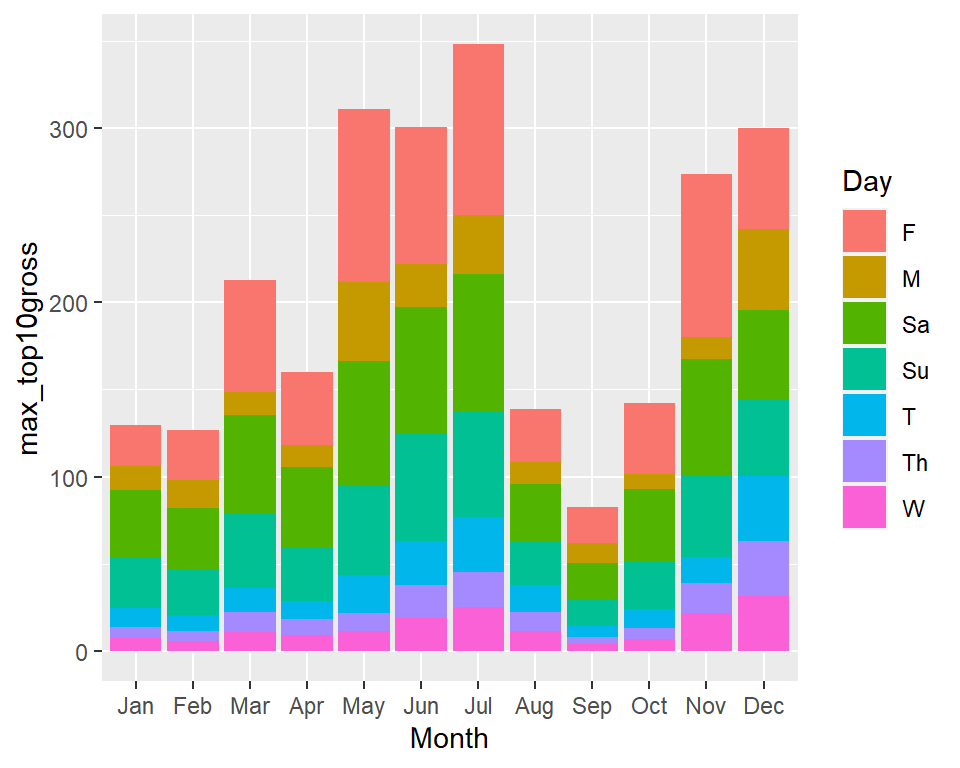

```r
(mojo_barplot <- mojo_22_long |> ggplot() +
  geom_bar(aes(x=Month, y=max_top10gross, fill=Day),
           stat="identity"))
```

### Stacked Barplot

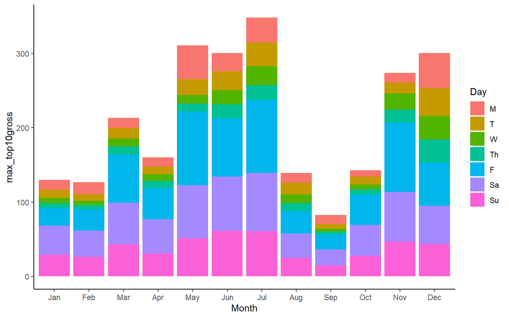

```r
mojo_22_long <- mojo_22_long |> # Day converted to factor to specify order
  mutate(Day = factor(Day, levels=c("M", "T", "W", "Th", "F", "Sa", "Su")))
(mojo_barplot <- mojo_22_long |>
  ggplot() +
  geom_bar(aes(x=Month, y=max_top10gross, fill=Day), stat="identity") +
  theme_classic())
```

### Side-by-side Barplot

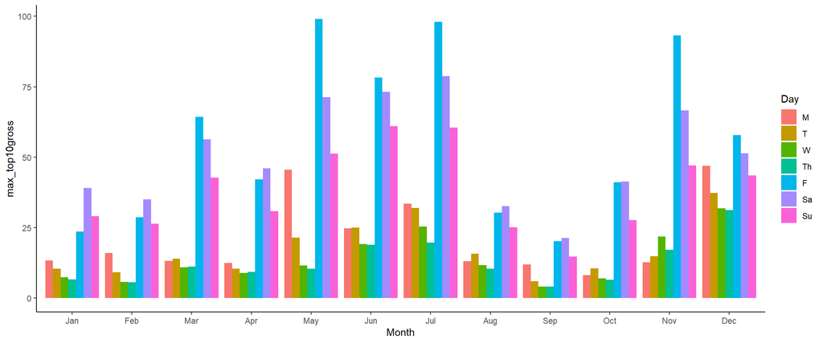

```r
(mojo_barplot <- mojo_22_long |>
  ggplot() +
  geom_bar(aes(x=Month, y=max_top10gross, fill=Day),
           stat="identity", position="dodge") +
  theme_classic())
```

### Labels Formatted

Now we can add on to the plot which is a saved object in the Global Environment

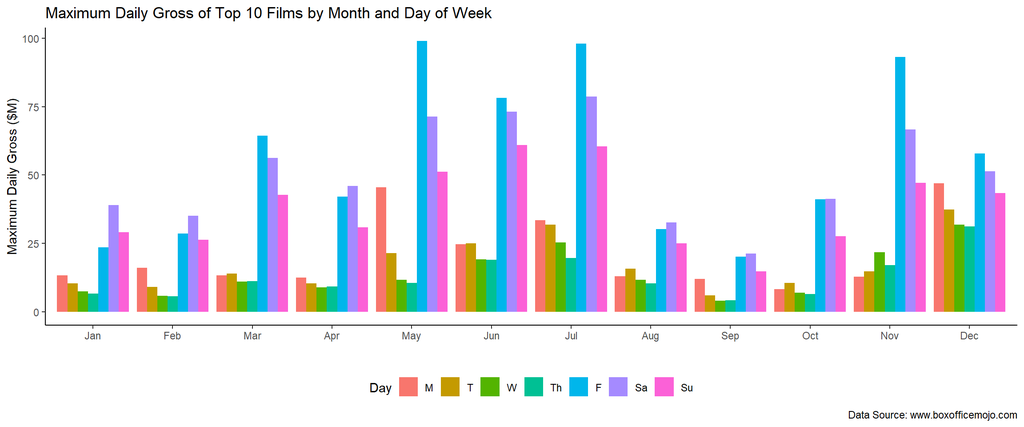

```r
(mojo_barplot <- mojo_barplot +
  theme(legend.position ="bottom") +
  guides(fill = guide_legend(nrow = 1)) +
  labs(x="", y="Maximum Daily Gross ($M)",
       title = "Maximum Daily Gross of Top 10 Films by Month and Day of Week",
       caption = "Data Source: www.boxofficemojo.com"))
```

### Spectral Palette with Text Resized

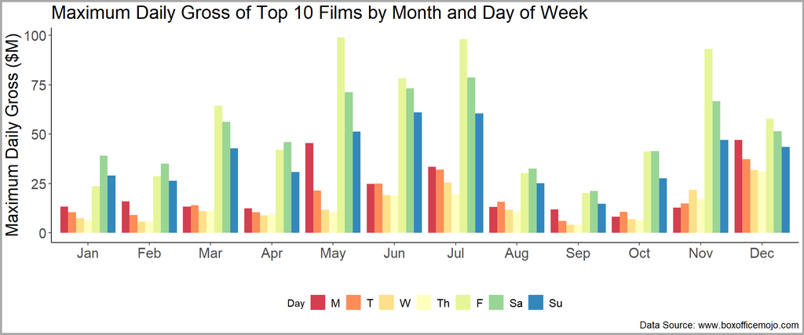

```r
(mojo_barplot <- mojo_barplot +
    scale_fill_brewer(palette = "Spectral") +
    theme(plot.title = element_text(size = 20),
        axis.title = element_text(size=18),
        axis.text = element_text(size=15),
        plot.caption = element_text(size = 10),
        legend.text = element_text(size = 12),
        plot.background = element_rect(colour = "darkgrey", fill=NA, size=2)))
```

class: middle

### Week 3 In-class Exercises (L5 - Q3)

*Session ID: bua455f24*

**This is part of BB Question 5 in HW 3**

If you want a grouped barplot with **side-by-side bars**, what is the correct option to include in the **`geom_bar`** statement?

**[Here is some additional information about geom_bar barplots.](https://ggplot2.tidyverse.org/reference/geom_bar.html)**

### `pivot_longer` for Line Plots and Areas Plots

- An alternative to summarizing the data is to show the data as a time series.
  - Two ways to do this are a **line plot** or an **area plot**
  - These plots are an effective data management and presentation tool.
- To make a line plot with multiple variables, we use pivot_longer to reshape the data.

```r
mojo_22_line_area <- mojo_22_mod |>
  select(date, top10grossM, num1grossM) |>                  # select variables
  rename(`Top 10` = top10grossM, `No. 1` = num1grossM) |>   # rename for plot
  pivot_longer(cols=`Top 10`:`No. 1`,                       # reshape data
               names_to = "type", values_to = "grossM") |>
  mutate(type=factor(type, levels=c("Top 10", "No. 1")))    # convert type of gross to a factor
head(mojo_22_line_area, 4)
```

```
## # A tibble: 4 × 3
##   date       type   grossM
##   <date>     <fct>   <dbl>
## 1 2022-12-31 Top 10   28.0
## 2 2022-12-31 No. 1    18.0
## 3 2022-12-30 Top 10   37.9
## 4 2022-12-30 No. 1    24.8
```

### Line Plot

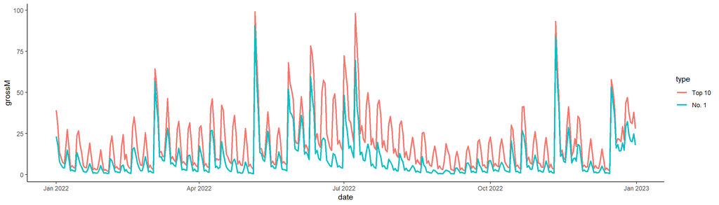

```r
(line_plt <- mojo_22_line_area |>
  ggplot() +
  geom_line(aes(x=date, y=grossM, color=type), size=1) + # two lines created #<<
  theme_classic())
```

### Labels & Colors Formatted

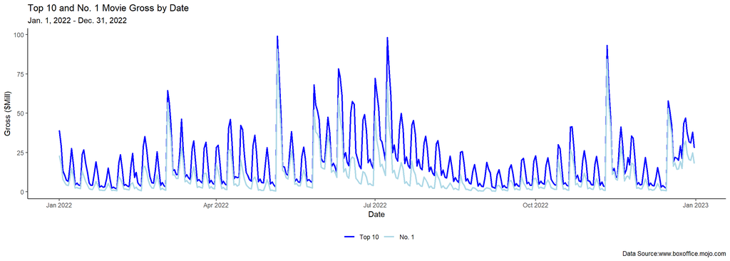

```r
(line_plt <- line_plt +
  theme(legend.position="bottom") +                    # legend at bottom #<<
  scale_color_manual(values=c("blue", "lightblue")) +  # specify colors   #<<
  labs(x="Date", y = "Gross ($Mill)", color="",
       title="Top 10 and No. 1 Movie Gross by Date",
       subtitle="Jan. 1, 2022 - Dec. 31, 2022",
       caption="Data Source:www.boxoffice.mojo.com"))
```

### Resize Text

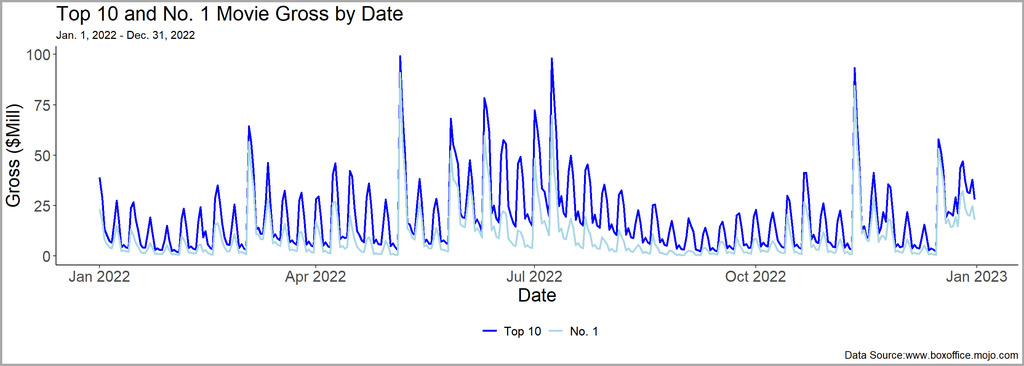

```r
(line_plt <- line_plt +
  theme(plot.title = element_text(size = 20),
        axis.title = element_text(size=18),
        axis.text = element_text(size=15),
        plot.caption = element_text(size = 10),
        legend.text = element_text(size = 12),
        plot.background = element_rect(colour = "darkgrey", fill=NA, size=2)))
```

### Complete Area Plot Code

Change `geom_line` to `geom_area` and `color` to `fill`

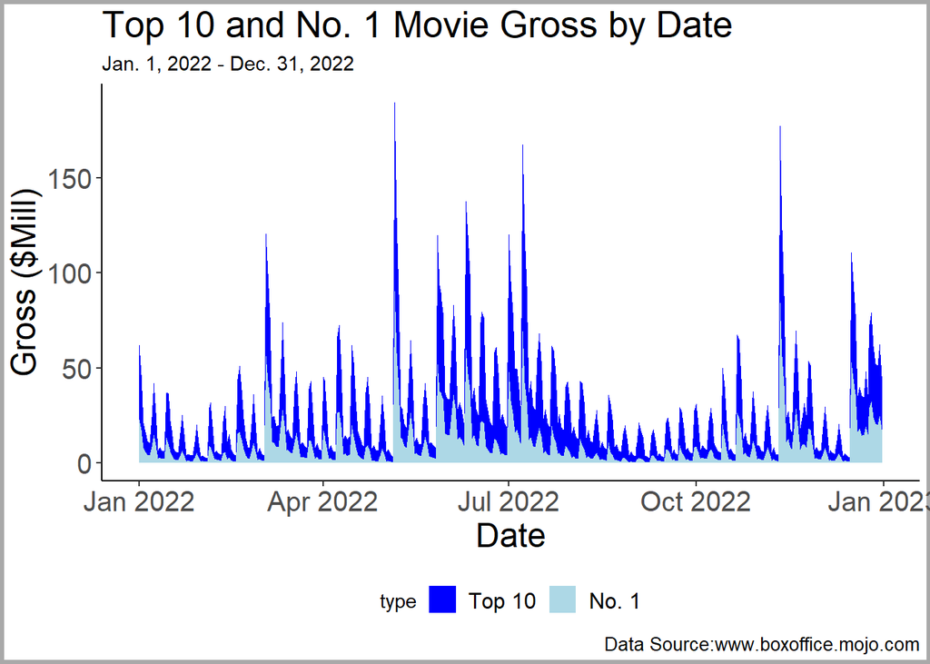

```r
(area_plt <- mojo_22_line_area |>
  ggplot() +
  geom_area(aes(x=date, y=grossM, fill=type), size=1) + # changed to geom_area and color to fill #<<
  theme_classic() +
  theme(legend.position="bottom") +
  scale_fill_manual(values=c("blue", "lightblue")) +    # changed color to fill   #<<
  labs(x="Date", y = "Gross ($Mill)", color="",
       title="Top 10 and No. 1 Movie Gross by Date",
       subtitle="Jan. 1, 2022 - Dec. 31, 2022",
       caption="Data Source:www.boxoffice.mojo.com") +
    theme(plot.title = element_text(size = 20),
        axis.title = element_text(size=18),
        axis.text = element_text(size=15),
        plot.caption = element_text(size = 10),
        legend.text = element_text(size = 12),
        plot.background = element_rect(colour = "darkgrey", fill=NA, size=2)))
```

### Week 3 In-class Exercises (L6 - Q1)

*NOT ON PointSolutions*

**Practice:**

- Running chunks and exporting a table.
- **Preview for 1 Question in Quiz 1 where you will:**
  - Select variables from a provided dataset
  - Group and summarize data
  - Export a summary table as a .csv file and submit it.

**Instructions:**

1. Save Week 3 R project to your computer
2. Open this project by clicking on .Rproj file
3. Open .Rmd file within open R project.
4. Run all chunks above this exercise
5. Modify the following chunk below to:
   1. Round all values in columns 2-4 of `mojo_22_fall_wknd` to 1 decimal place using `round`.
   2. Export `mojo_22_fall_wknd` as a `.csv` file with your name.
6. Submit this .csv file with your name in the **Week 3 In-class Exercise** in the **LECTURES** section on Blackboard

**NOTE:** This counts as part of your in-class participation for the Week 3 lectures (due Fri. at midnight).

### R Code Chunk for In-class Exercise (L6 - Q1)

0. Remove `, eval=F` from chunk header. This will allow code in chunk to run when it is rendered.
1. Remove the `#` and complete `round` command to round numeric columns (columns 2 - 4) to 1 decimal place.
2. Choose EITHER of the `write_csv` commands and edit it so dataset will be exported to `code_data_output` folder with your name.
3. Delete `write_csv` command you don’t edit or put `#` symbols in front of it.
4. Submit `.csv file` with your name

```r
# examine data with glimpse
mojo_22_fall_wknd |> glimpse()

# rounding columns 2, 3 and 4 only
# mojo_22_fall_wknd[,2:4] <- round()

# export summary dataset using write_csv without piping
write_csv(mojo_22_fall_wknd, "Movie_Gross_Fall_2022_Weekends_FirstName_Last_Name.csv")

# export summary dataset using write_csv with piping
mojo_22_fall_wknd |>
  write_csv("Movie_Gross_Fall_2022_Weekends_FirstName_Last_Name.csv")
```

class: middle

### Week 3 In-class Exercises (L6 - Q2)

*NOT ON PointSolutions*

If all the columns in a dataset are numeric, you can round the whole dataset at once with the command `round(<name of dataset>)`.

Why wouldn’t that work for the dataset in the previous exercise, `mojo_22_fall_wknd`?

Hint: To answer this question, you are encourage to

- try running the command `round(mojo_22_fall_wknd)`
- examine the data using `glimpse`

class: middle

### Week 3 In-class Exercises (L6 - Q3)

*Session ID: bua455f24*

Which of the following commands should **NOT** be used within a `mutate` command or a `summarize` command?

- `as.integer`
- `factor`
- `mean`
- `filter`

### HW 3 Introduction

#### Purpose

This assignment will give you experience with:

- Creating an R Project Directory and a code_data_output folder (Review)
- Creating, saving, using an R Markdown file (Review)
- Importing data
- Knitting an R Markdown file to create an word document (Review)
- Creating a README file (Review)
- Using the dplyr commands along with commands to reshape and summarize data
- Creating plots with some formatting

class: middle

In HW 3, you will group the data by quarter and week day. This is Part 4 of HW 3 and is very similar to the group_by and summarize code covered in Lecture 5.

### Week 3 In-class Exercises (L6 - Q4)

*Session ID: bua455f24*

**This is BB Question 3 in HW 3**

Your grouped and summarized dataset, **`mojo_qtr_smry`**, has

`____` rows and

`____` columns

`____` summary numeric variables

### **Key Points from Week 3**

**Summarizing Data by Group**

- Use `group_by` to specify grouping variables
- Followed by `summarize`
  - Within summarize specify type:
  - .e.g. `mean`, `meadian`, `max`, etc.

**Reshaping Data for Different Purposes**

- `pivot_wider` is useful for display tables
- `pivot_longer` is useful for plots

**Plotting Data**

- grouped barplots (stacked and side-by-side)
- line plots and area plots

You may submit an ‘Engagement Question’ about each lecture until midnight on the day of the lecture. **A minimum of four submissions are required during the semester.**